# EEMB 146 Final Project

Kai Barker

2026-03-01

# Kai Barker: Examining the Effects of Temperature and Acidification on the Growth of *Neoagarum fimbriatum*

## Abstract

This study aims to understand the effects of temperature and pH on kelp growth to demonstrate how changing climate conditions could potentially impact ocean ecosystems. Using a dataset compiled by BCO-DMO containing kelp growth data, temperature, and pH conditions we can test our hypothesis that both factors will have an effect on the growth of the kelp species *Neoagarum fimbriatum*. To test this hypothesis, we ran both a two-sample t-test and fit a linear model to interpret the effects of these variables on kelp growth. It was found that the effects of the pH groups were an insignificant influence, while temperature and the starting weight of the kelp did play a more important role. With global temperatures continuing to rise, this study points to the possible impacts to many marine ecosystems.

## Introduction

Kelp forests are vital ecosystems in marine environments, providing habitat, nursery grounds, and food resources for numerous species while playing a critical role in creating fuel for the marine food chain (Britton et al., 2016; Fernández et al., 2015). High-latitude kelp forests are increasingly exposed to two main stressors, ocean warming (OW) and ocean acidification (OA). By 2100, surface ocean pH is projected to decline by approximately 0.3-0.4 units and $CO_2$ concentrations are expected to double relative to current levels (Fernández et al., 2015).

The response of kelp species to these factors are highly variable and dependent on the species itself. Responses to elevated $CO_2$ levels depend heavily on the species’ carbon acquisition strategy and broader environmental and seasonal factors. For *Macrocystis pyrifera* specifically, neither photosynthetic nor growth rates were significantly affected by elevated $CO_2$ and reduced pH projected for the end of the century, likely due to its efficient use of $HCO_3-$ (bicarbonate) as a carbon source (Fernández et al., 2015). However, the authors note that the effects of OA combined with temperature and availability of nutrients could alter this response. Similarly, Britton et al. (2016) found that while natural changes in pH benefited *Ecklonia radiata* growth under simulated current conditions, it saw a negative effect on growth rates under simulated OA conditions. Thus we observe that kelp species responses are dependent on environmental and seasonal conditions.

Seasonal variation in light and nutrient availability only further complicates these interactions, particularly at high latitudes where winter conditions limit primary production (Kroeker, BCO-DMO). In our study, we utilize the dataset collected by Dr. Kristy Kroeker and her Ph.D. student Lauren Bell (of UC Santa Cruz). Through two month-long laboratory experiments in Alaska representing winter (February 12-March 18 2020) and summer (August 15-September 16, 2020) seasonal conditions, they examined the effects of temperature and pH on three high-latitude kelp species. These species were the Giant Kelp (*Macrocystis pyrifera*) and two understory species (*Neoagarum fimbriatum* and *Hedophyllum nigripes*). Findings from this research suggest that *Macrocystis pyrifera* showed resilience to projected warming temperatures and acidification, while the understory kelps showed a decrease in biomass and nutritional quality under warming conditions (Kroeker, BCO-DMO).

For the purposes of our paper, we will only study one of the understory kelp species *Neoagarum fimbriatum* (NFIM), and the change in its growth dependent on pH and temperature. There will be four variables studied, the starting wet weight of the kelp after it has been trimmed down to ~10cm (measured in grams), the change in wet weight from the start to the end of the measured experiment (g), the temperature (control/OW), and the pH (control/OA). Over the one species of kelp, we have 144 observations in the dataset. This research paper aims to answer if ocean warming and acidification will negatively impact kelp growth. Thus, we hypothesize that both temperature and pH will have a statistically significant effect on the growth of *Neoagarum fimbriatum*.

## Exploratory Data Analysis

First we will select the variables from the dataset (Appendix 1) and visualize the distributions of our numeric variables of interest, the change in wet weight (change_ww) and the starting wet weight (START_ww).

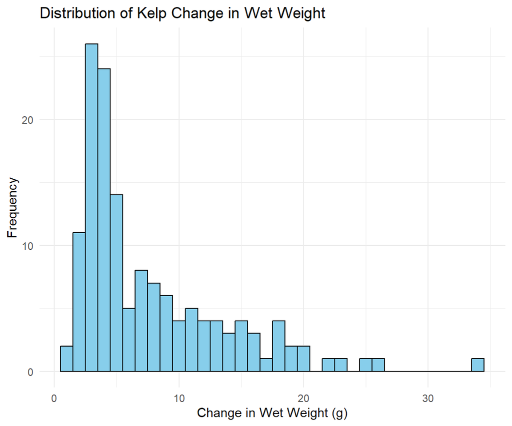

**Figure 1: Histogram of Kelp Change in Wet Weight**

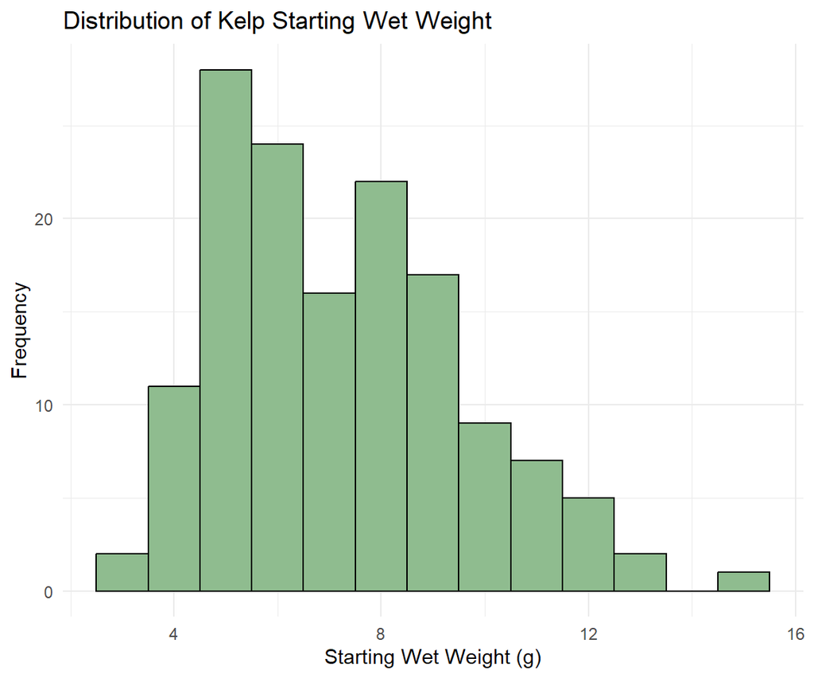

We can observe from Figures 1 and 2 that the distribution of the change in wet weight does not appear normally distributed, as the distribution is significantly right skewed, with an apparent outlier around 35. However, the distribution of the starting wet weight appears more normally distributed with no distinct outliers. Both variables show a wide range of values with most values being clustered under 10g for the change, and most values clustered between 4-8g for the starting weight.

Additionally we will check the normality of our dependent variable, change_ww.

Table 1: Change in Wet Weight Shapiro-Wilk Results

|  | W | p_value |
| --- | --- | --- |
| W | 0.8373764 | 2.5e-11 |

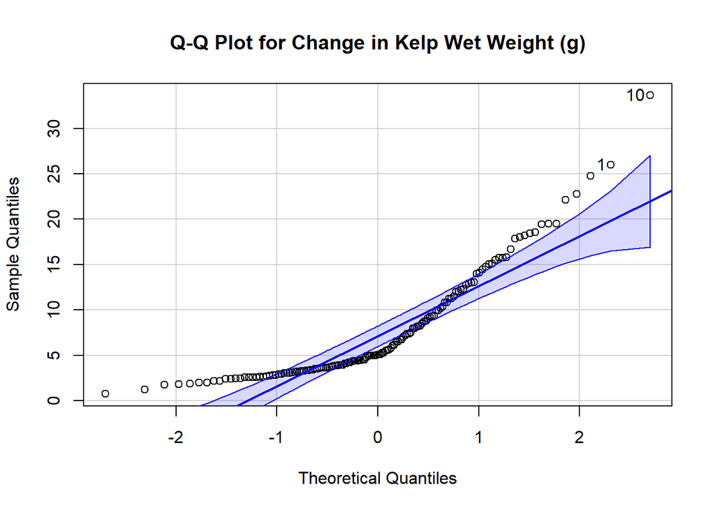

**Figure 3: Q-Q Plot for Change in Kelp Wet Weight**

```
## [1] 10  1
```

After performing a Shapiro-Wilk Normality test (Table 1), we can observe a p-value of $2.472e-11$, so at significance level $\alpha = 0.05$, we can conclude that the data significantly deviates from a normal distribution. Furthermore, in Figure 3 the change_ww variable visibly shows a significant deviation from the normal line and outside of the blue confidence bands. Thus we will try log and square root transforming the dependent variable to evaluate if that affects normality.

Table 2: Log Change in Wet Weight Shapiro-Wilk Results

| W | p_value |
| --- | --- |
| 0.9634534 | 0.000698 |

Table 3: Sqrt Change in Wet Weight Shapiro-Wilk Results

| W | p_value |
| --- | --- |
| 0.9268238 | 9e-07 |

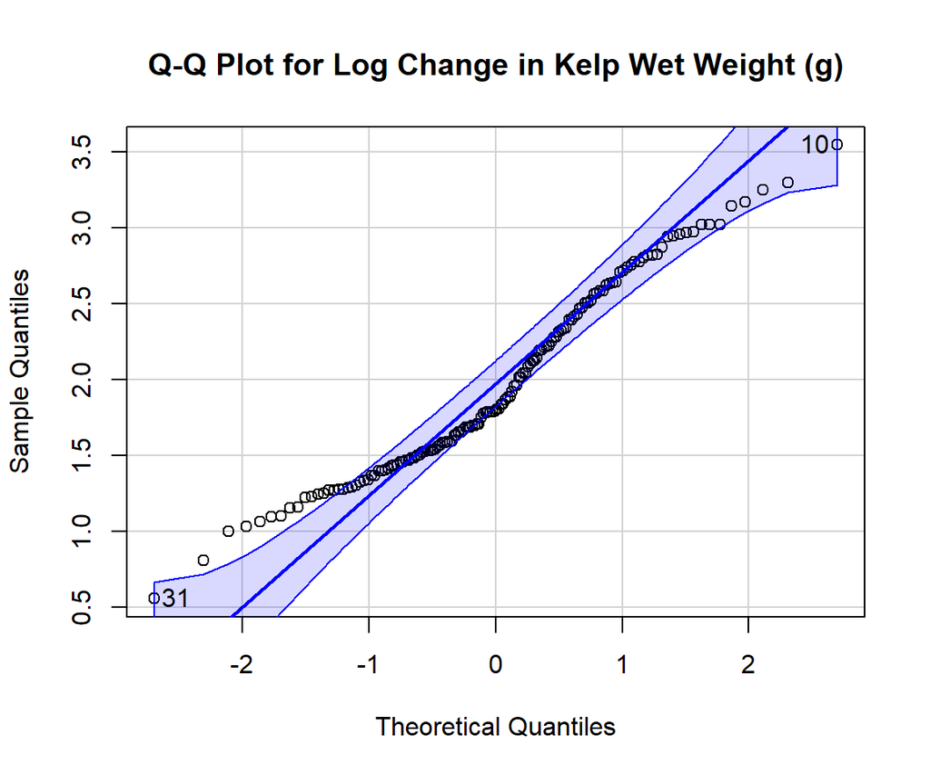

**Figures 4 & 5: Q-Q Plots for Transformed Change in Wet Weight (Log and Sqrt Respectively)**

```
## [1] 10 31
```

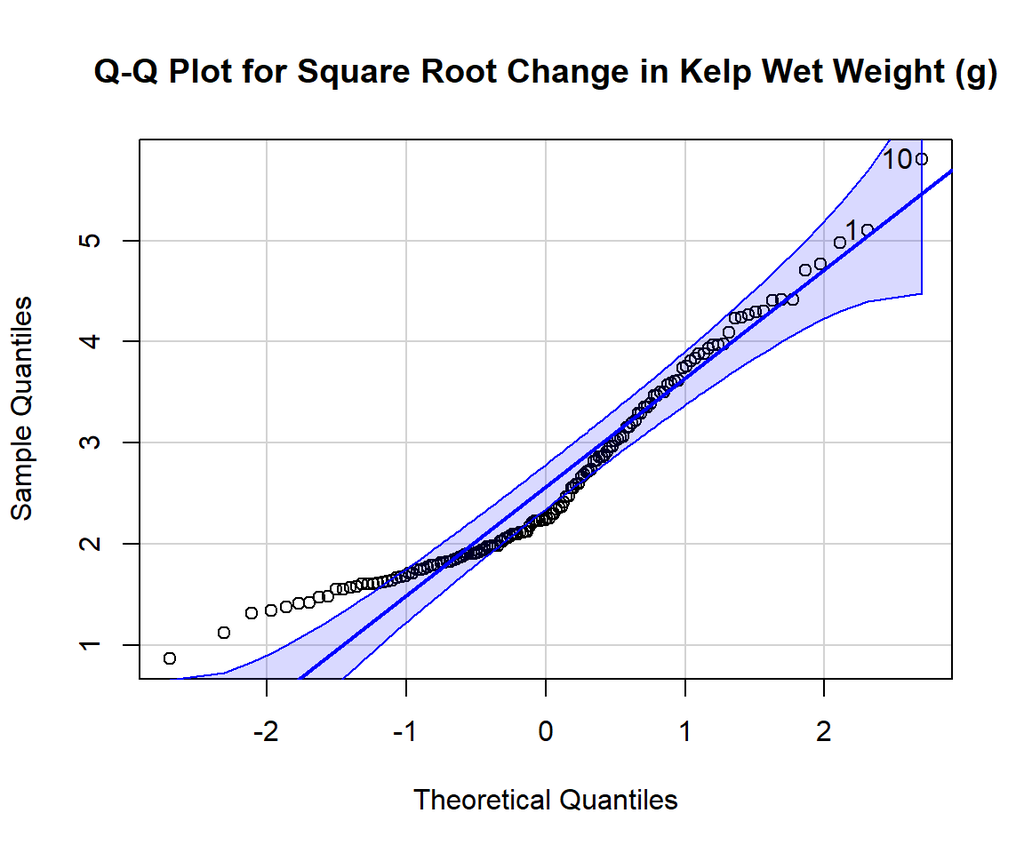

**Figures 4 & 5: Q-Q Plots for Transformed Change in Wet Weight (Log and Sqrt Respectively)**

```
## [1] 10  1
```

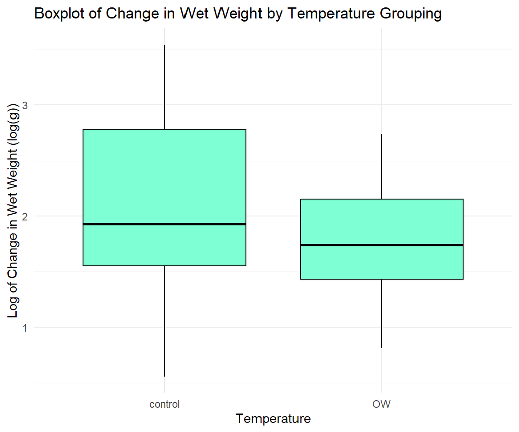

**Figure 6: Boxplot for Log Change of Wet Weight by Temperature**

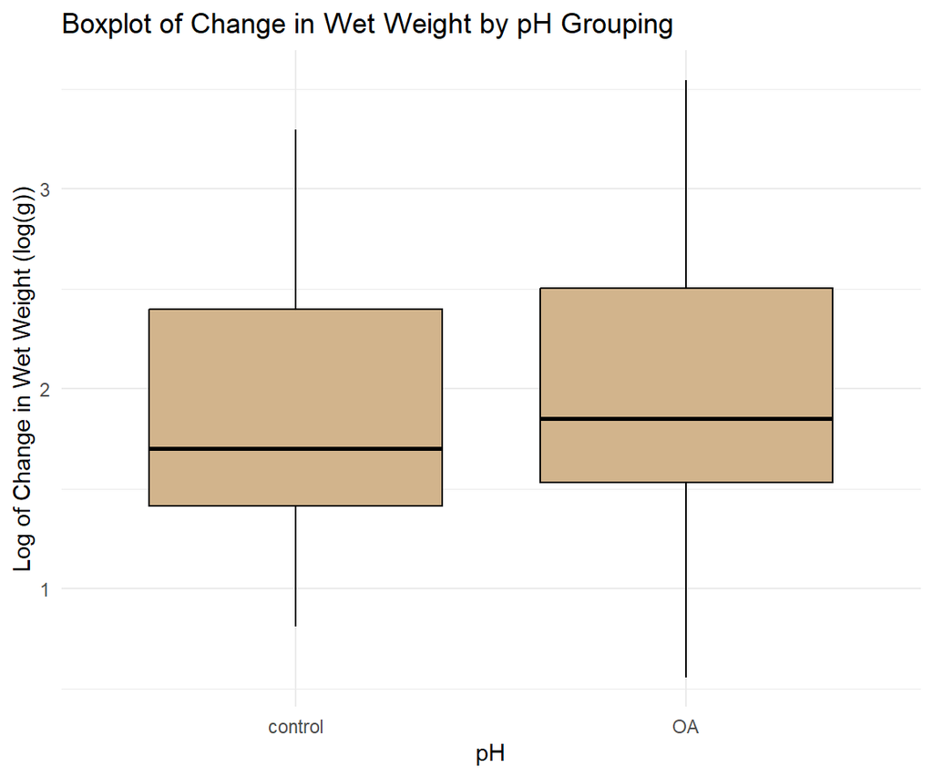

**Figure 7: Boxplot for Log Change of Wet Weight by pH**

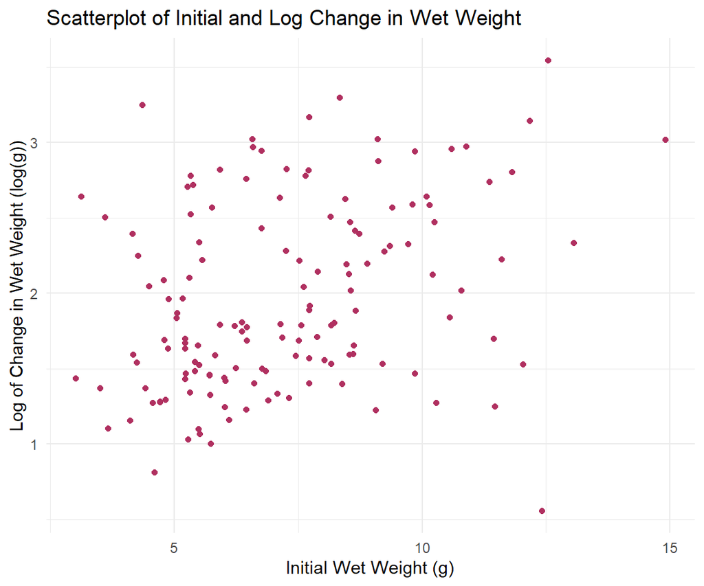

**Figure 8: Scatterplot of Starting Weight against Log Change in Wet Weight**

## Statistical Methods

Table 4: Levene’s Test for Temperature Grouping

| Df | F value | Pr(>F) |
| --- | --- | --- |
| 1 | 18.46338 | 3.2e-05 |
| 142 | NA | NA |

Table 5: Levene’s Test for pH Grouping

| Df | F value | Pr(>F) |
| --- | --- | --- |
| 1 | 0.7610619 | 0.3844691 |
| 142 | NA | NA |

Written explicitly, our hypothesis for the two-sample t-test is:
$$H_0: \mu_c = \mu_{OA}$$
$$H_A: \mu_c \neq \mu_{OA}$$
Where $\mu_c$ is the mean of the control group and $\mu_{OA}$ is the mean of the OA group.

(See Appendix 2, or Results section for t-test output)

Additionally, we will fit a linear model to predict the log change in wet weight based on the starting wet weight, temperature, and pH group. The explicit hypothesis for the model is:
$$H_0: \beta_1=\beta_2=\beta_3=0$$
Where $\beta_1, \beta_2, \beta_3$ are the coefficients for START_ww, Temp, and pH respectively.
$$H_A: \text{At least one } \beta \neq 0$$

To ensure the validity of the regression results (see Appendix 3, or the Results section for table), we can observe the Shapiro-Wilk test (Table 6) for the residuals, as well as the Q-Q residuals and residuals vs. fitted plots (Figure 9).

Table 6: Shapiro-Wilk of Residuals

| W | p_value |
| --- | --- |
| 0.9762317 | 0.0131357 |

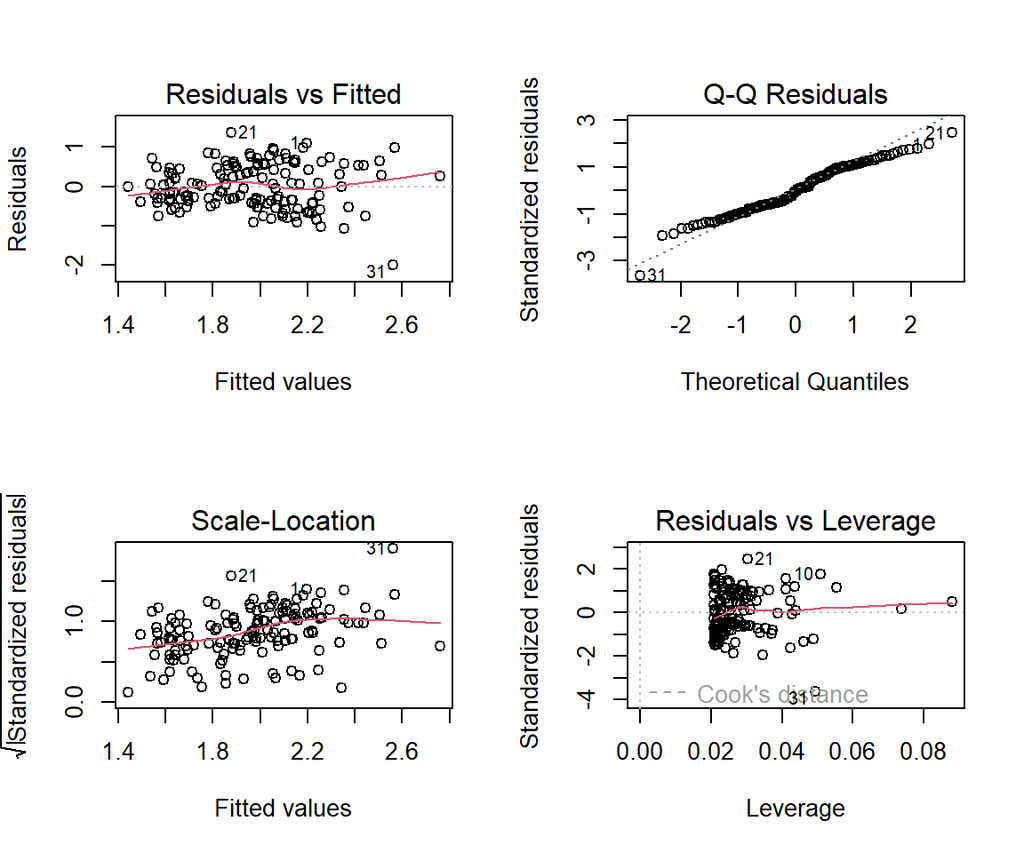

**Figure 9: Linear Model Plots**

Table 7: VIFs for Linear Model Predictors

|  | x |
| --- | --- |
| START_ww | 1.029636 |
| Temp | 1.005455 |
| pH | 1.024181 |

## Results

Table 8: Two-Sample t-test Results

| Statistic | df | p_value |
| --- | --- | --- |
| -0.8992842 | 142 | 0.3700237 |

The two-sample t-test of log change in wet weight by pH grouping had a resulting p-value of $0.37$, with a control group mean of $1.92$ and a OA group mean of $2.01$. At significance level $\alpha = 0.05$, we fail to reject the null hypothesis, and conclude that there is not enough evidence to claim a significant difference in the two means. Thus the mean of the pH control group is not significantly different than the mean of the OA group.

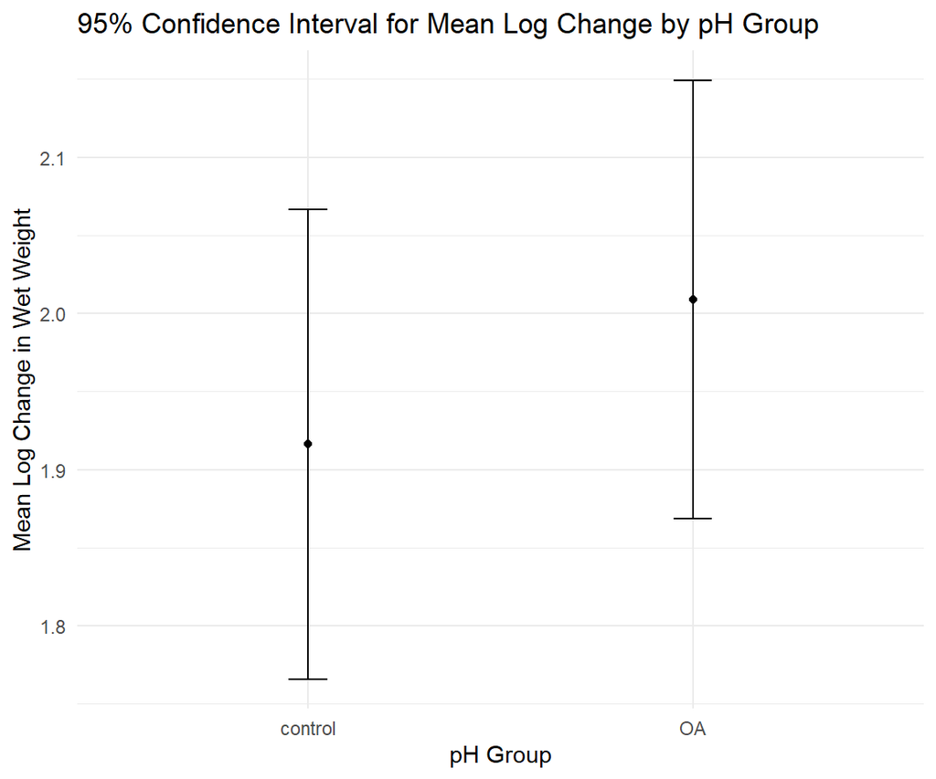

**Figure 10: Confidence Interval Plot**

The 95% confidence interval (from t-Test, see Appendix 2) for the difference in means between the control and OA pH groups is roughly $(-0.297, 0.111)$. Since this interval contains zero then we fail to reject the null hypothesis, which is consistent with the resulting p-value from the t-test. This again suggests that there is no significant difference in mean log change in wet weight for the two pH groups. From Figure 10, we can see that the error bars of both groups overlap, indicating that the true means of each group can be possibly within the other groups interval, again supporting no significant difference between the group means.

The second statistical test ran was a linear model to predict the log change in wet weight from predictors of starting wet weight, temperature OW group, and pH OA group. The results of the model are as shown.

Table 9: Linear Model Results

|  | Estimate | Std. Error | t value | Pr(>\|t\|) |
| --- | --- | --- | --- | --- |
| (Intercept) | 1.5283044 | 0.1665220 | 9.1777943 | 0.0000000 |
| START_ww | 0.0801506 | 0.0205629 | 3.8978308 | 0.0001499 |
| TempOW | -0.3278492 | 0.0946800 | -3.4627094 | 0.0007097 |
| pHOA | 0.0354938 | 0.0955576 | 0.3714394 | 0.7108718 |

## Discussion

In order to test our hypothesis that both temperature and pH have a statistically significant effect on the growth of *Neoagarum fimbriatum*, we ran two statistical tests. The variable of interest, change in wet weight, was first log transformed in order for it to better follow a normal distribution. A two-sample t-test was run to compare the log change in wet weight and the two pH groups present in the data, control and ocean acidification (OA). The t-test resulted in a p-value of $0.37$, meaning that at significance level $\alpha = 0.05$, we failed to reject the tests null hypothesis, and concluded that there was not significant evidence to support a difference in means of the two groups. Thus implying that there is insufficient evidence that pH significantly affects log change in wet weight, as the two groups means are not statistically different.

A linear model was fit to predict the log change in wet weight using the kelps starting wet weight, temperature group, and pH group. The model had an overall p-value of $4.578e-06$, meaning that we rejected the null hypothesis in favor of the alternate, and concluded that at least one of the coefficients is significantly different from zero. We can observe that the only coefficient, including the intercept, that is not highly significant and greater than $\alpha = 0.05$ is the predictor for the OA pH group. This means that the temperature and starting weight both have significant effects on the log change in wet weight, while the OA pH group does not. The models adjusted $R^2$ value showed that our model explained approximately 16% of variation in the log change of wet weight. This is not uncommon for ecological data as unmeasured factors can contribute substantially to the variability. However, the small value is worth noting and should be further looked in to, as it weakens the interpretation of our results.

The two tests inform each other in that the t-test shows that the pH groups do not differ in means, and the linear model suggests that the OA pH group is not a significant predictor once temperature and starting wet weight is accounted for. This implies that temperature could be a stronger influence on log change in wet weight. This consistency across both tests supports both temperature and starting weight as more influential factors of kelp growth than pH in this environment.

From our statistical tests, we gain insight into how different factors affect the kelp in our specific ecosystem. As discussed previously, prior research has shown that kelp growth is variable and dependent on seasonal and environmental factors. Using the data from Dr. Kroeker’s research simulating both winter and summer conditions, and focusing on the *Neoagarum fimbriatum* species, we can make the following observations about the system. The starting wet weight of the kelp has a significant effect on the log change in wet weight with the OW temperature group also significantly contributing to log change compared to baseline levels. The OA pH group was found not to significantly contribute to kelp log change in weight, and the lack of evidence to support a difference in pH group means from the t-test further shows that pH is at least a less important variable in this system. More rigorous statistical testing would be needed to further investigate the effects of pH on this system, which as previously stated, could have more significant effects on different kelp species or when studied in different environments. Future studies on this data could explore such possibilities, as well as explore larger samples of the kelp or the other species in the data that were not included in our study. Another limitation of our study is the small adjusted $R^2$ value indicates poor model fit, and a model that includes additional predictors, a different transformation or a larger sample could potentially improve this. Similarly, we could expand our studied variables, as we do not include light or nutrient availability in our analysis, both critical factors for kelp growth. A limitation of the data coming from an experiment with a short duration (two month-long periods) is that it could limit our understanding of long-term patterns.

Given that temperature was found to be a significant predictor of log change in wet weight, and with rising ocean temperatures driven by climate change, there could be meaningful implications for kelp growth in ecosystems similar to this one. If ocean temperatures continue to rise, then we may observe changes in kelp biomass as kelp wet weight decreases. Reduced kelp biomass in these ocean ecosystems would cause serious harm to marine life that relies on kelp as nurseries, food, and shelter. This study and ones similar to it provide an early foundation for understanding how individual environmental factors may negatively effect kelp ecosystems.

## References

Bell, L. E., Kroeker, K. J. (2023). Kelp growth data from seasonal global change experiments examining the effects of seasonal variation in light availability and nutrients on the response of three high-latitude kelp species. Biological and Chemical Oceanography Data Management Office (BCO-DMO). (Version 1) Version Date 2023-08-16 [if applicable, indicate subset used]. doi:10.26008/1912/bco-dmo.906317.1 2026, March 1

Britton, D., Cornwall, C. E., Revill, A. T., Hurd, C. L., & Johnson, C. R. (2016, May 27). Ocean acidification reverses the positive effects of seawater ph fluctuations on growth and photosynthesis of the habitat-forming kelp, Ecklonia radiata. Nature News. https://www.nature.com/articles/srep26036

Fernandez, P. A., Roleda, M. Y., & Hurd, C. L. (2015, April 14). Effects of ocean acidification on the photosynthetic performance, carbonic anhydrase activity and growth of the giant kelp macrocystis pyrifera - photosynthesis research. SpringerLink. https://link.springer.com/article/10.1007/s11120-015-0138-5

Fox, J., & Weisberg, S. (2019). An R companion to applied regression (3rd ed.). Sage. https://www.john-fox.ca/Companion/

Kroeker, K. J. (n.d.). Career: Energy fluxes and community stability in a dynamic, high-latitude Kelp Ecosystem. ADS. https://ui.adsabs.harvard.edu/abs/2018nsf….1752600K/abstract

Wickham, H., Averick, M., Bryan, J., Chang, W., McGowan, L. D., François, R., Grolemund, G., Hayes, A., Henry, L., Hester, J., Kuhn, M., Pedersen, T. L., Miller, E., Bache, S. M., Müller, K., Ooms, J., Robinson, D., Seidel, D. P., Spinu, V., . . . Yutani, H. (2019). Welcome to the tidyverse. Journal of Open Source Software, 4(43), 1686. https://doi.org/10.21105/joss.01686

Wickham, H. (2016). ggplot2: Elegant graphics for data analysis. Springer-Verlag. https://ggplot2.tidyverse.org

Xie, Y. (2014). knitr: A comprehensive tool for reproducible research in R. In V. Stodden, F. Leisch, & R. D. Peng (Eds.), Implementing reproducible computational research. Chapman and Hall/CRC.

## Appendix

```r
#load the data and packages
#dataset 145
kelp_data <- read.csv("data/dataset_145.csv")

#for pipe operator and for graphing
#citation: Wickham H, Averick M, Bryan J, Chang W, McGowan LD, François R, Grolemund G, Hayes A, Henry L, Hester J, Kuhn M, Pedersen TL, Miller E, Bache SM, Müller K, Ooms J, Robinson D, Seidel DP, Spinu V, Takahashi K, Vaughan D, Wilke C, Woo K, Yutani H (2019). “Welcome to the tidyverse.” Journal of Open Source Software, 4(43), 1686. doi:10.21105/joss.01686.
library(tidyverse)

#citation: Wickham H (2016). ggplot2: Elegant Graphics for Data Analysis. Springer-Verlag New York. ISBN 978-3-319-24277-4, https://ggplot2.tidyverse.org.
library(ggplot2)

#for levenes test and for VIF
#Fox J, Weisberg S (2019). An R Companion to Applied Regression, Third edition. Sage, Thousand Oaks CA. https://www.john-fox.ca/Companion/.
library(car)

#for making my tables look nice in the results section
#Xie Y (2014). “knitr: A Comprehensive Tool for Reproducible Research in R.” In Stodden V, Leisch F, Peng RD (eds.), Implementing Reproducible Computational Research. Chapman and Hall/CRC. ISBN 978-1466561595.
library(knitr)
```

**Appendix 1:**

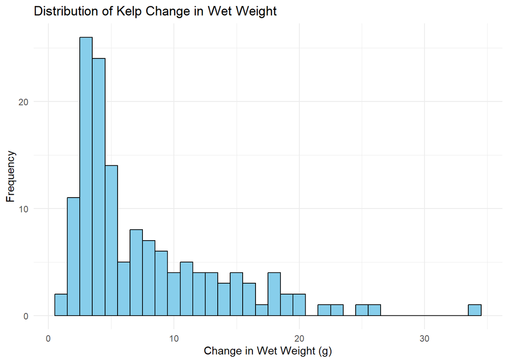

**Figure 1: Histogram of Kelp Change in Wet Weight**

```r
#Appendix 1

# we want to subset the data like we did in the project check in
kelp_subset <- kelp_data %>%
  select(Temp, pH, START_ww, change_ww)

clean_kelp <- kelp_subset %>% #select all columns included in analysis
  drop_na()

#also change the categorical variables to factors
clean_kelp$Temp <- as.factor(clean_kelp$Temp)
clean_kelp$pH <- as.factor(clean_kelp$pH)

# first lets start by visualizing the different variables
# plot the histograms of the numeric y

ggplot(clean_kelp, aes(x=change_ww)) +
  geom_histogram(binwidth=1, color="black", fill="skyblue") +
  labs(x="Change in Wet Weight (g)", y="Frequency", title="Distribution of Kelp Change in Wet Weight") +
  theme_minimal()
```

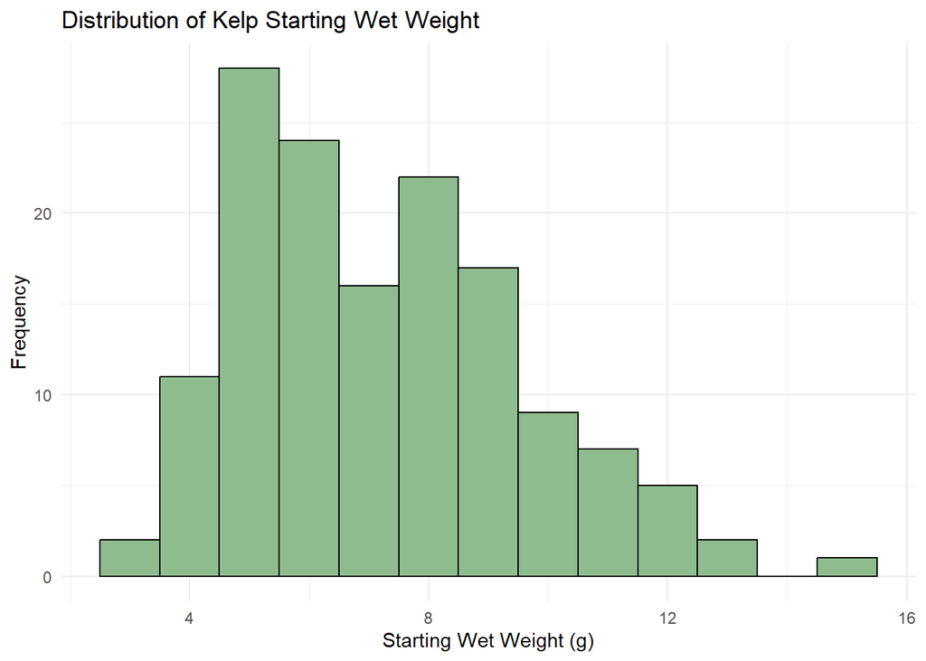

```r
# then histogram for numeric x
ggplot(clean_kelp, aes(x=START_ww)) +
  geom_histogram(binwidth=1, color="black", fill="darkseagreen") +
  labs(x="Starting Wet Weight (g)", y="Frequency", title="Distribution of Kelp Starting Wet Weight") +
  theme_minimal()
```

```r
# then since it doesnt look normal check shapiro wilk/qqplot and then transform and check that
shap_change <- shapiro.test(clean_kelp$change_ww)
shap_table1 <- data.frame(W=shap_change$statistic, p_value=shap_change$p.value)
kable(shap_table1, caption="Change in Wet Weight Shapiro-Wilk Results")
```

Change in Wet Weight Shapiro-Wilk Results

|  | W | p_value |
| --- | --- | --- |
| W | 0.8373764 | 0 |

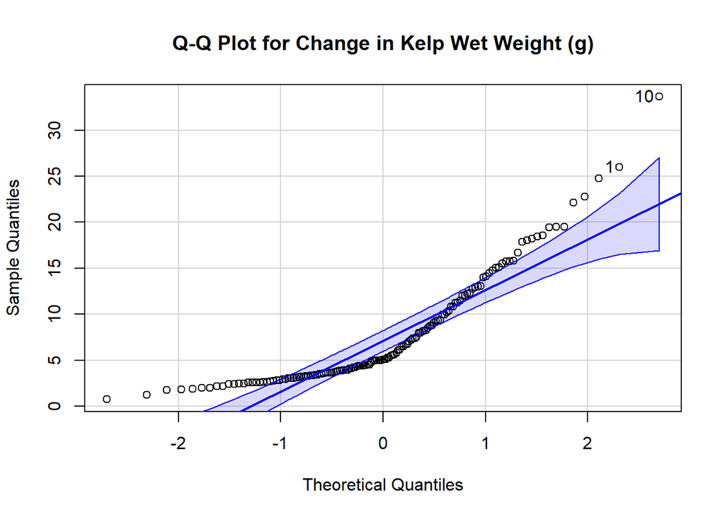

**Figure 3: Q-Q Plot for Change in Kelp Wet Weight**

```
## [1] 10  1
```

```r
#make the qqplot and add labels
qqPlot(clean_kelp$change_ww, xlab="Theoretical Quantiles", ylab="Sample Quantiles", main="Q-Q Plot for Change in Kelp Wet Weight (g)")
```

```r
#try log
shap_logchange <- shapiro.test(log(clean_kelp$change_ww+1))
#try sqrt
shap_sqrtchange <- shapiro.test(sqrt(clean_kelp$change_ww))

shap_table2 <- data.frame(W=shap_logchange$statistic, p_value=shap_logchange$p.value)
shap_table3 <- data.frame(W=shap_sqrtchange$statistic, p_value=shap_sqrtchange$p.value)
kable(shap_table2, caption="Log Change in Wet Weight Shapiro-Wilk Results", row.names=FALSE)
```

Log Change in Wet Weight Shapiro-Wilk Results

| W | p_value |
| --- | --- |
| 0.9634534 | 0.000698 |

```r
kable(shap_table3, caption="Sqrt Change in Wet Weight Shapiro-Wilk Results", row.names=FALSE)
```

Sqrt Change in Wet Weight Shapiro-Wilk Results

| W | p_value |
| --- | --- |
| 0.9268238 | 9e-07 |

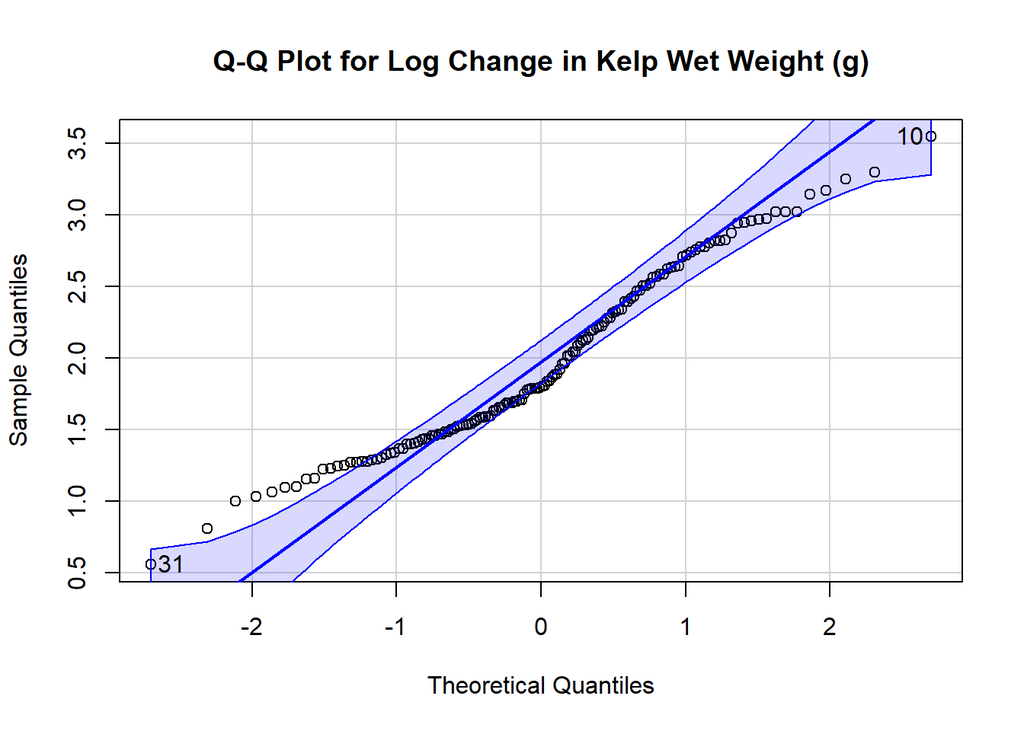

**Figures 4 & 5: Q-Q Plots for Transformed Change in Wet Weight (Log and Sqrt Respectively)**

```
## [1] 10 31
```

```r
#qqplots and label them, for the log and sqrt transforms
qqPlot(log(clean_kelp$change_ww+1), xlab="Theoretical Quantiles", ylab="Sample Quantiles", main="Q-Q Plot for Log Change in Kelp Wet Weight (g)")
```

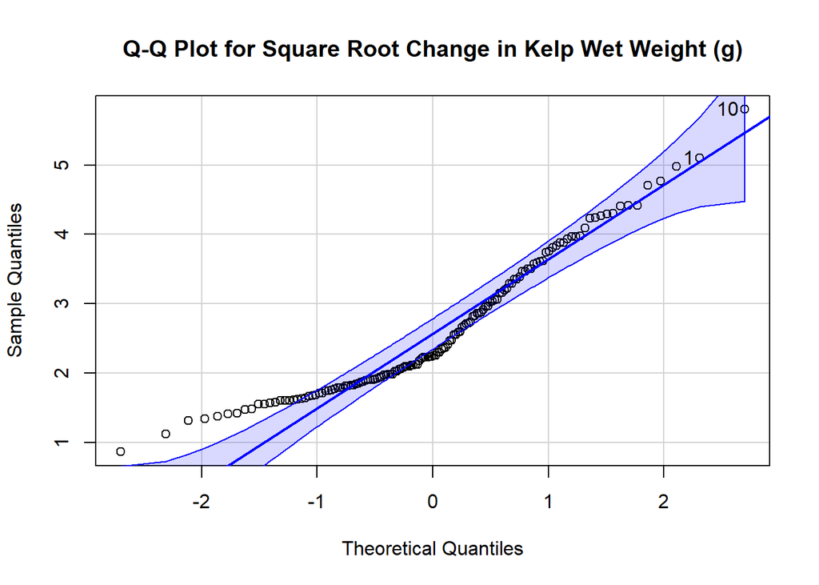

**Figures 4 & 5: Q-Q Plots for Transformed Change in Wet Weight (Log and Sqrt Respectively)**

```
## [1] 10  1
```

```r
qqPlot(sqrt(clean_kelp$change_ww), xlab="Theoretical Quantiles", ylab="Sample Quantiles", main="Q-Q Plot for Square Root Change in Kelp Wet Weight (g)")
```

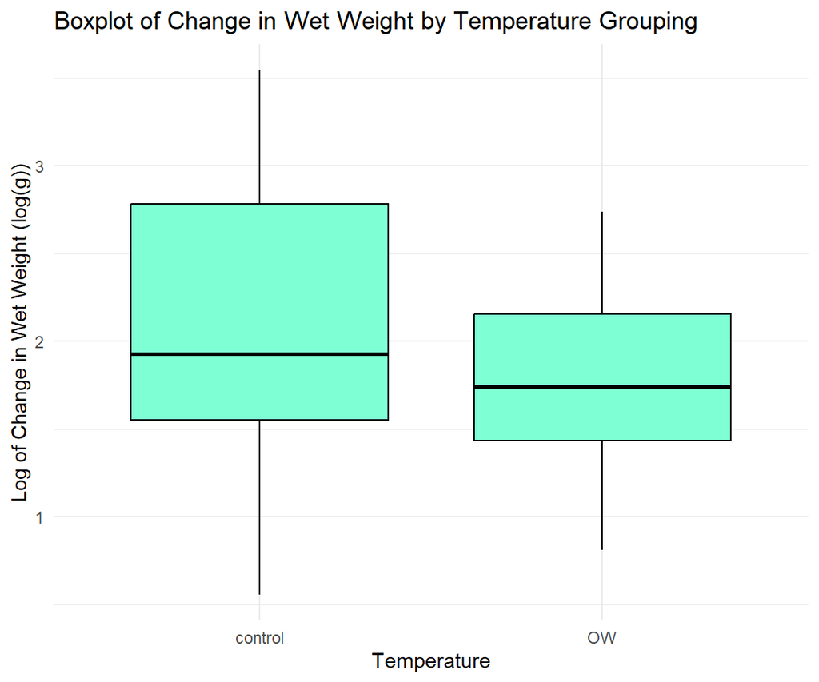

**Figure 6: Boxplot for Log Change of Wet Weight by Temperature**

```r
# box plot for y against temp
#using log transformation since that was the closest to normal
ggplot(clean_kelp, aes(x=Temp, y=log(change_ww+1))) +
  geom_boxplot(color="black", fill="aquamarine") +
  labs(x="Temperature", y="Log of Change in Wet Weight (log(g))", title="Boxplot of Change in Wet Weight by Temperature Grouping") +
  theme_minimal()
```

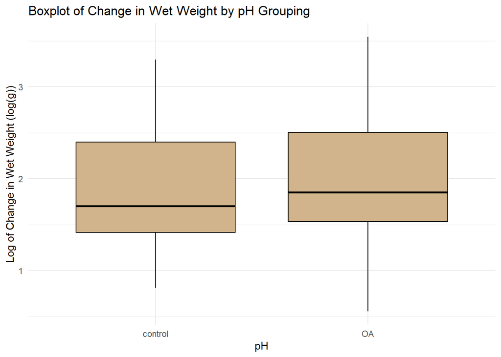

**Figure 7: Boxplot for Log Change of Wet Weight by pH**

```r
# box plot for y against ph
ggplot(clean_kelp, aes(x=pH, y=log(change_ww+1))) +
  geom_boxplot(color="black", fill="tan") +
  labs(x="pH", y="Log of Change in Wet Weight (log(g))", title="Boxplot of Change in Wet Weight by pH Grouping") +
  theme_minimal()
```

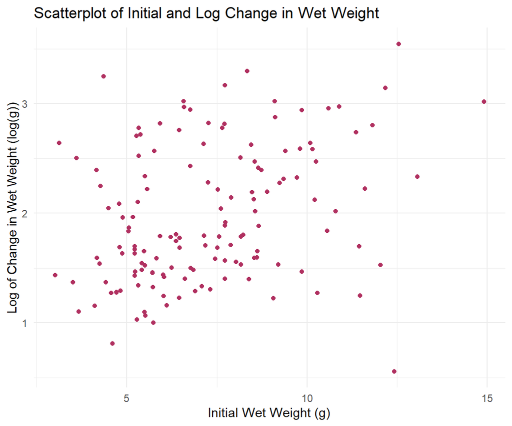

**Figure 8: Scatterplot of Starting Weight against Log Change in Wet Weight**

```r
# scatterplot for y against numeric x
ggplot(clean_kelp, aes(x=START_ww, y=log(change_ww+1))) +
  geom_point(color="maroon") +
  labs(x="Initial Wet Weight (g)", y="Log of Change in Wet Weight (log(g))", title="Scatterplot of Initial and Log Change in Wet Weight") +
  theme_minimal()
```

```r
#run a levene test to check for equality of variance
#add the log change var
clean_kelp$log_change <- log(clean_kelp$change_ww + 1)

#then run test for both categorical variables and save them as variables so I can make kable tables
lev_temp <- leveneTest(clean_kelp$log_change, group=clean_kelp$Temp)
lev_ph <- leveneTest(clean_kelp$log_change, group=clean_kelp$pH)

#make the tables so it has a nice clean output
kable(lev_temp, caption="Levene's Test for Temperature Grouping", row.names=FALSE)
```

Levene’s Test for Temperature Grouping

| Df | F value | Pr(>F) |
| --- | --- | --- |
| 1 | 18.46338 | 3.2e-05 |
| 142 | NA | NA |

```r
kable(lev_ph, caption="Levene's Test for pH Grouping", row.names=FALSE)
```

Levene’s Test for pH Grouping

| Df | F value | Pr(>F) |
| --- | --- | --- |
| 1 | 0.7610619 | 0.3844691 |
| 142 | NA | NA |

**Appendix 2:**

```r
#Appendix 2

# test 1 since we have 144 observations, the shapiro wilk value is closer to 0.05 but can be thrown off with larger samples
# and the qqplot looks approx normal as discussed in these sections
test1 <- t.test(log_change ~ pH, data=clean_kelp, var.equal=TRUE)
test1
```

```
##
##  Two Sample t-test
##
## data:  log_change by pH
## t = -0.89928, df = 142, p-value = 0.37
## alternative hypothesis: true difference in means between group control and group OA is not equal to 0
## 95 percent confidence interval:
##  -0.2965541  0.1111038
## sample estimates:
## mean in group control      mean in group OA
##              1.916213              2.008938
```

**Appendix 3:**

```r
#Appendix 3

#fit the linear model on the log change with all variables in the cleaned dataset as predictors
# following in the report will be the validation of the model assumptions
test2 <- lm(log_change ~ START_ww + Temp + pH, clean_kelp)
test2
```

```
##
## Call:
## lm(formula = log_change ~ START_ww + Temp + pH, data = clean_kelp)
##
## Coefficients:
## (Intercept)     START_ww       TempOW         pHOA
##     1.52830      0.08015     -0.32785      0.03549
```

```r
# check the plots to verify assumptions for linear model are met, and check the normality of the residuals with shapiro wilk too
shap_linmodel <- shapiro.test(test2$residuals)
shap_table4 <- data.frame(W=shap_linmodel$statistic, p_value=shap_linmodel$p.value)
kable(shap_table4, caption="Shapiro-Wilk of Residuals", row.names=FALSE)
```

Shapiro-Wilk of Residuals

| W | p_value |
| --- | --- |
| 0.9762317 | 0.0131357 |

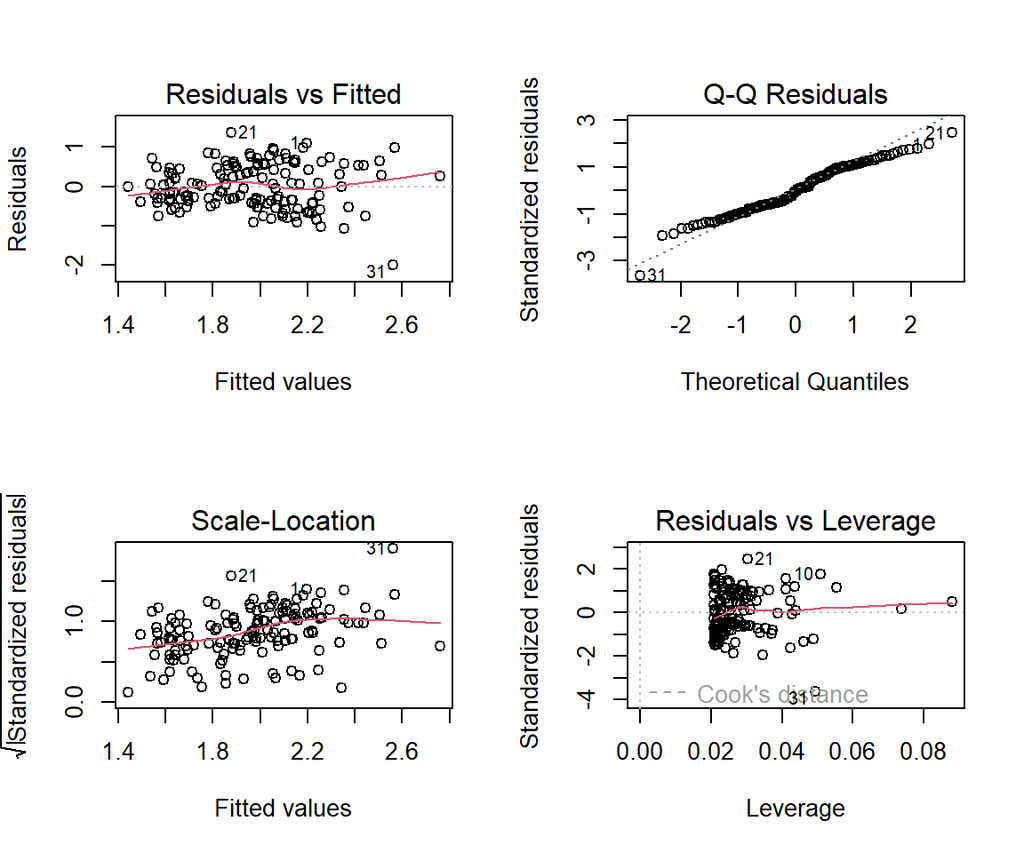

**Figure 9: Linear Model Plots**

```r
#plot a 2x2 to save space, I plotted them each seperately and make them bigger so I could analyze for my assumptions
#but for the purposes of the finished paper I made them smaller and 2x2
par(mfrow=c(2,2))
plot(test2)
```

```r
#VIF
#most of my stats classes have chosen VIF < 5 is good
vif_vals <- vif(test2)
kable(vif_vals, caption="VIFs for Linear Model Predictors")
```

VIFs for Linear Model Predictors

|  | x |
| --- | --- |
| START_ww | 1.029636 |
| Temp | 1.005455 |
| pH | 1.024181 |

```r
#make a table with the information from the t test
t_test_table <- data.frame(Statistic = test1$statistic, df=test1$parameter, p_value=test1$p.value)
kable(t_test_table, caption="Two-Sample t-test", row.names=FALSE)
```

Two-Sample t-test

| Statistic | df | p_value |
| --- | --- | --- |
| -0.8992842 | 142 | 0.3700237 |

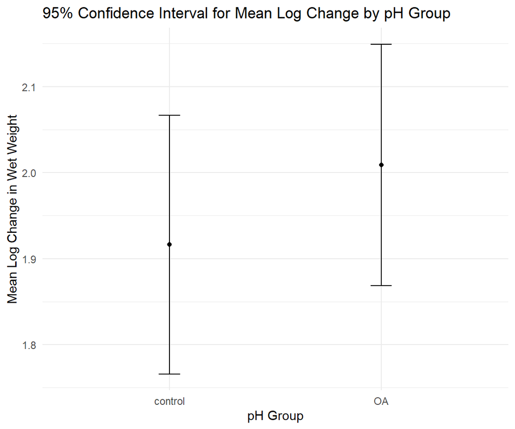

**Figure 10: Confidence Interval Plot**

```r
# we want to plot the confidence interval as well so for this
ci_data <- clean_kelp %>%
  group_by(pH) %>%
  summarise(
    mean = mean(log_change),
    se = sd(log_change)/sqrt(n()),
    lower = mean - qt(0.975, n()-1) * se,
    upper = mean + qt(0.975, n()-1) * se
  )

#then plot this confidence interval
ggplot(ci_data, aes(x=pH, y=mean)) +
  geom_point() +
  geom_errorbar(aes(ymin=lower, ymax=upper), width=0.1) +
  labs(x="pH Group", y="Mean Log Change in Wet Weight",
       title="95% Confidence Interval for Mean Log Change by pH Group") +
  theme_minimal()
```

```r
#get the summary of the linear model but make it a variable for the kable table
lm_summary <- summary(test2)$coefficients
kable(lm_summary, caption="Linear Model Results")
```

Linear Model Results

|  | Estimate | Std. Error | t value | Pr(>\|t\|) |
| --- | --- | --- | --- | --- |
| (Intercept) | 1.5283044 | 0.1665220 | 9.1777943 | 0.0000000 |
| START_ww | 0.0801506 | 0.0205629 | 3.8978308 | 0.0001499 |
| TempOW | -0.3278492 | 0.0946800 | -3.4627094 | 0.0007097 |
| pHOA | 0.0354938 | 0.0955576 | 0.3714394 | 0.7108718 |